# Lesson 3 Introduction

ANTH 102-W1

Now you have a grasp of the basic “how to” of archaeology, particularly with respect to *observing* and *collecting* archaeological data, we will start bridging the gap between data collection to interpretation by looking at how archaeologists *analyze* that data.

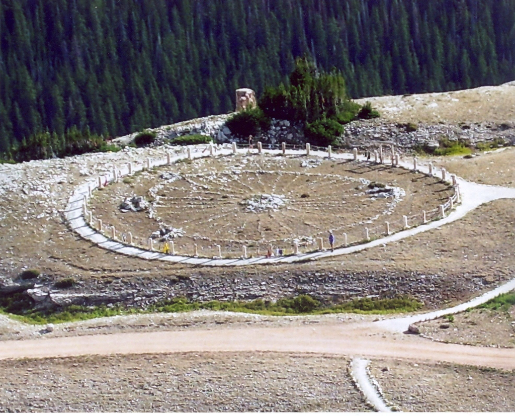

Bighorn Medicine Wheel

As an archaeologist, one must try to avoid the trap of thinking about all human behavior in the past tense. Consider this specific property in downtown New York City (pictured below). Many people attach varied meanings and feelings to geographic space/place; this is how we create our **cultural landscape**.

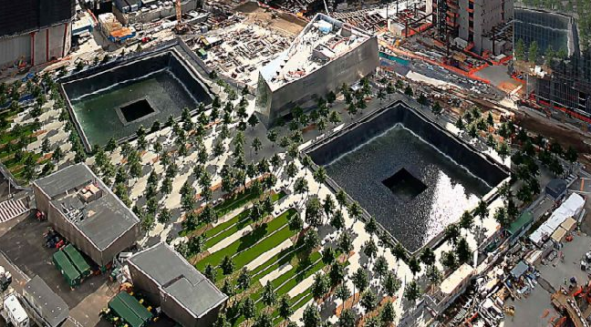

National September 11 Memorial & Museum

In this lesson, we will focus on the methods that archaeologists use to analyze their data and, eventually, interpret the results of those analyses in order to reconstruct the past. It may help to skim over previous readings, just to refresh yourself with some of the terminology that we have already covered.

Here are some links of interest:

- [Early metallurgy](http://pages.ucsd.edu/~dkjordan/arch/metallurgy.html)
- [Ceramic analysis](http://mvac.uwlax.edu/ProcessArch/lab_ceramic.html)
- [Bioarchaeology](https://bonesdontlie.wordpress.com/2012/02/09/resources-for-bioarchaeology-and-mortuary-archaeology-news/)

### Objectives

By the end of this lesson, you should be able to successfully:

- Describe the process of artifact classification, particularly through **typologies**.
- What are the most common materials of archaeological artifacts, and what do we know about their manufacture?
- Describe the concept of a **sacred space**, from the perspective of archaeology (and anthropology, generally) and connect to some archaeological examples using evidence from archaeo-astronomy.
- Describe the **main goals of archaeological research** and some of the theoretical approaches that archaeologists use to reconstruct past human systems and recognize their own biases that may influence their interpretations.
- Describe the ways archaeologists attempt to reconstruct the “intangible” (e.g., inequality in the past, **gender** in the archaeological record, **social ranking** and **stratification**).

#### Continue

Continue through the module to access more.